# Prediction of Suicidal Ideation

Aysenur Okan

2024-04-16

# Decision Trees

## Fit decision tree using rpart

The biggest predictors of suicidal ideation were feeling sad during the interaction (>3) and Negative Affectivity (>2.3). Then, I got the complexity parameter to see if my model overfit the data and could improve by pruning. The complexity parameter was very small (cp = 0.011), indicating that the model did not suffer from complexity.

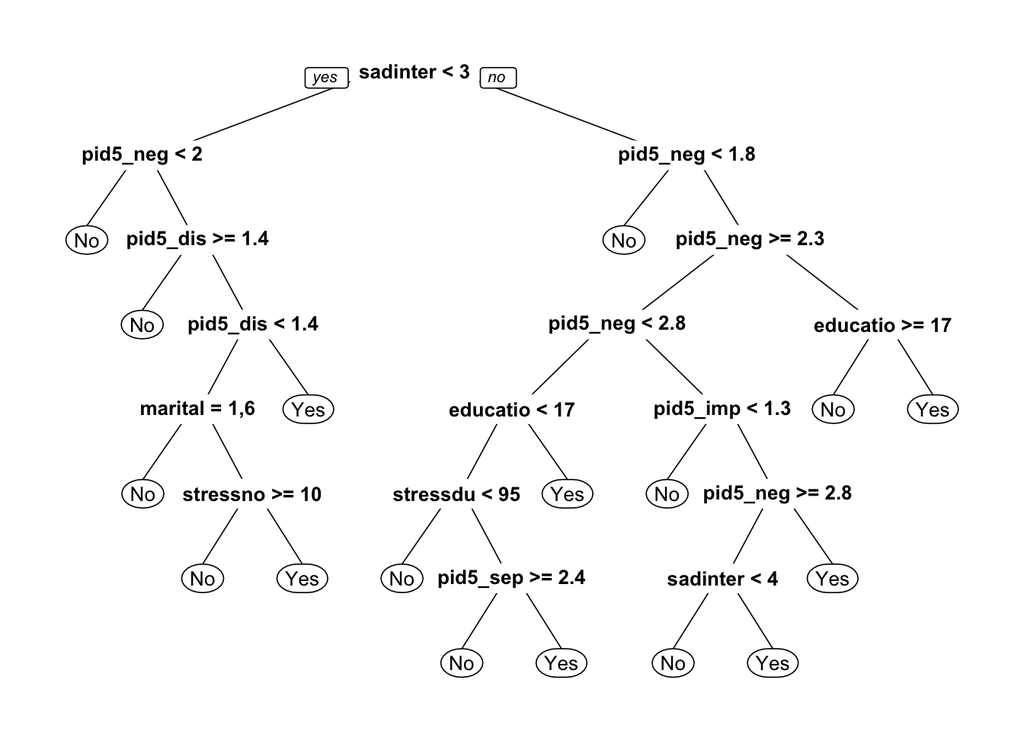

```r
set.seed(41)
tree.rpart=rpart(SI_Binary~. -id,data=df) #predict suicidal ideation choice from all predictors
prp(tree.rpart) #plot the decision tree
```

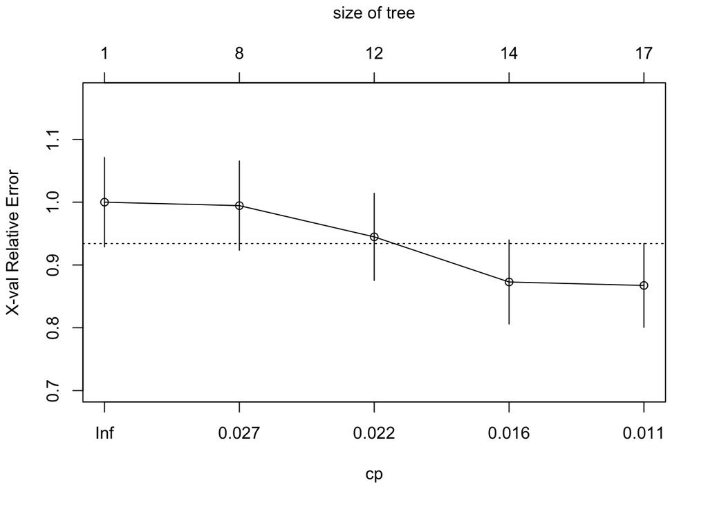

```r
plotcp(tree.rpart)
```

```r
#(1 s.e. from minimum error in the left out fold)
printcp(tree.rpart) #similar, but now with numbers, not the plot
```

```
##
## Classification tree:
## rpart(formula = SI_Binary ~ . - id, data = df)
##
## Variables actually used in tree construction:
## [1] education                 marital
## [3] pid5_disinhibition        pid5_impulsivity
## [5] pid5_negativeaffect       pid5_separationinsecurity
## [7] sadinteraction            stressduringinteraction
## [9] stressnowinteraction
##
## Root node error: 181/2189 = 0.082686
##
## n= 2189
##
##         CP nsplit rel error  xerror     xstd
## 1 0.030387      0   1.00000 1.00000 0.071190
## 2 0.024862      7   0.77348 0.99448 0.071011
## 3 0.019337     11   0.67403 0.94475 0.069368
## 4 0.012891     13   0.63536 0.87293 0.066893
## 5 0.010000     16   0.59669 0.86740 0.066698
```

## Prune tree

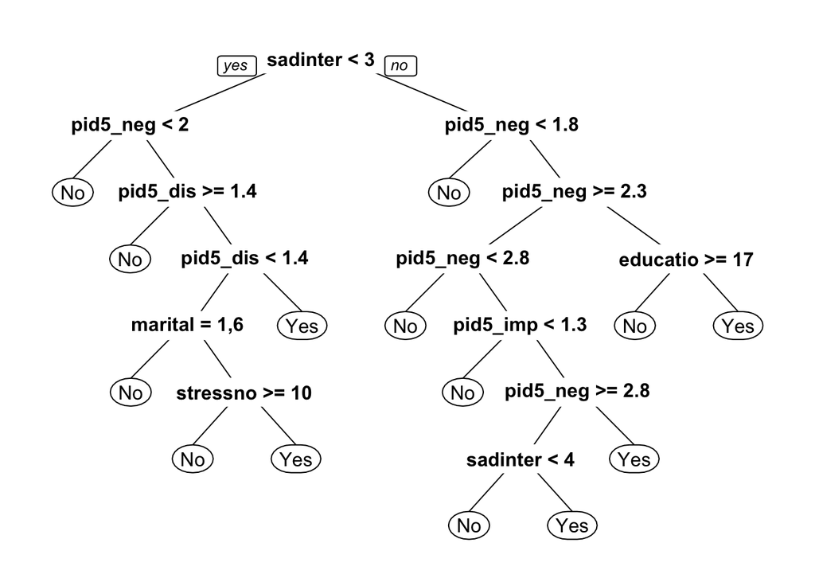

```r
tree.rpartp=prune(tree.rpart,cp=.013) #extract the tree with the determined complexity parameter; #adding "p" to signal that it is the pruned one
prp(tree.rpartp) #plot the pruned tree
```

## Examine the prediction error of the full tree with the test dataset

Next, I examine the prediction error of the full tree and the pruned tree in the testing dataset.

```r
#prediction error for full tree
pred.rpart=predict(tree.rpart,newdata=tsdf,type='class') #predicted values
table(pred.rpart,tsdf$SI_Binary) #cross-tabulation table (observed values are in columns)
```

```
##
## pred.rpart  No Yes
##        No  988  33
##        Yes  24  54
```

```r
miss.rpart=1-mean(pred.rpart==tsdf$SI_Binary, na.rm = T) #0-1 loss
miss.rpart # misclassification rate
```

```
## [1] 0.05186533
```

## Examine the prediction error of the pruned tree in the testing dataset

```r
#prediction error for pruned tree
pred.rpartp=predict(tree.rpartp,newdata=tsdf,type='class')
table(pred.rpartp,tsdf$SI_Binary)
```

```
##
## pred.rpartp  No Yes
##         No  992  41
##         Yes  20  46
```

```r
miss.rpartp=1-mean(pred.rpartp==tsdf$SI_Binary, na.rm = T)
miss.rpartp
```

```
## [1] 0.055505
```

# Ensemble Methods

## Bagging with `randomForest()`

```r
bag1=randomForest(SI_Binary~.-id,data=df,mtry=23,ntree=800) #bagging model; `mtry` function argument controls the number of predictors considered every time the tree makes a split. If the `mtry` values equals the number of predictors, then the randomForest function does bagging.

bagpred=predict(bag1,tsdf,type='response') #obtain predicted values from testing dataset
bag.table=table(bagpred,tsdf$SI_Binary) #cross-tabulation (rows are predicted, columns are observed
bag.table
```

```
##
## bagpred   No  Yes
##     No  1012    0
##     Yes    0   87
```

```r
1-(mean(bagpred==tsdf$SI_Binary))
```

```
## [1] 0
```

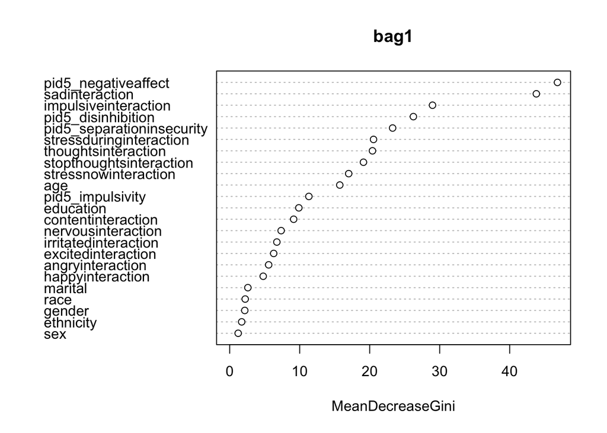

```r
varImpPlot(bag1) #plot variable importance measures
```

## Random Forest

```r
# Predicting SI_Binary with random forest on the training dataset
rf=randomForest(SI_Binary~.-id,data=df,mtry=7,ntree=800) #use 7 vars at a time (7 random predictors as candidates to split on), 400 trees grown in bootstrapped datasets.
#obtain the predicted values in the testing dataset
rfpred=predict(rf,tsdf,type='response')
# cross-tabulation of the classes
rf.table=table(rfpred,tsdf$SI_Binary)
#the variable importance measures.
rf.table
```

```
##
## rfpred   No  Yes
##    No  1011    0
##    Yes    1   87
```

```r
1-(mean(rfpred==tsdf$SI_Binary))
```

```
## [1] 0.0009099181
```

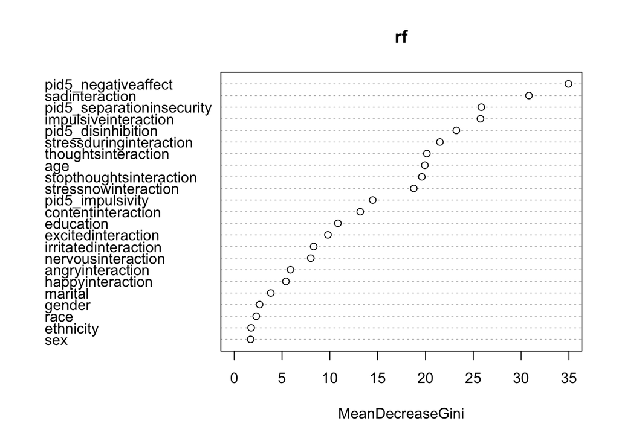

```r
varImpPlot(rf)
```

### try 5 tuning parameters and the previously-specified cross-validation routine.

```r
set.seed(2000)
#Fit Model
train.rf=train(SI_Binary~.,data=df,method='rf',tuneLength=5,trControl=trctrl)
#See tuning parameters
train.rf
```

```
## Random Forest
##
## 2189 samples
##   24 predictor
##    2 classes: 'No', 'Yes'
##
## No pre-processing
## Resampling: Cross-Validated (5 fold)
## Summary of sample sizes: 1752, 1751, 1752, 1750, 1751
## Resampling results across tuning parameters:
##
##   mtry  Accuracy   Kappa
##    2    0.9323907  0.3277715
##    9    0.9415252  0.5402864
##   17    0.9415263  0.5532364
##   25    0.9433517  0.5737282
##   33    0.9415283  0.5619166
##
## Accuracy was used to select the optimal model using the largest value.
## The final value used for the model was mtry = 25.
```

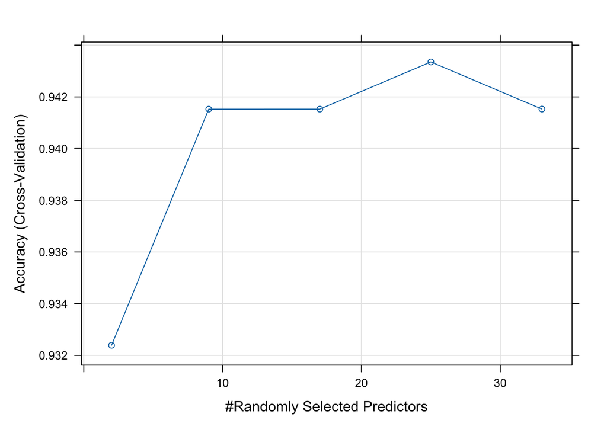

```r
plot(train.rf)
```

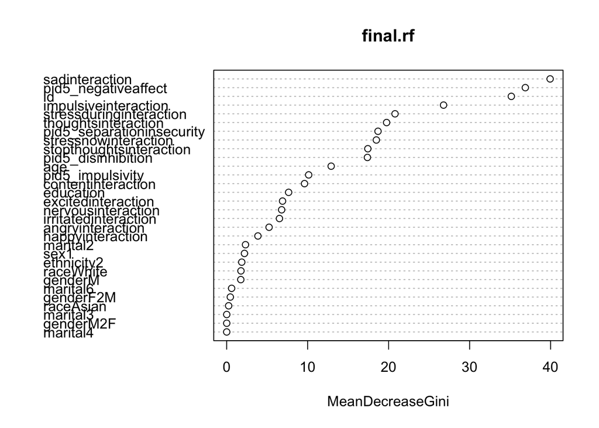

```r
final.rf=train.rf$finalModel
varImpPlot(final.rf)
```

### Fit the random forest with mtry = 9

```r
# Predicting SI_Binary with random forest on the training dataset
rf=randomForest(SI_Binary~.-id,data=df,mtry=9,ntree=800) #use 7 vars at a time (7 random predictors as candidates to split on), 400 trees grown in bootstrapped datasets.
#obtain the predicted values in the testing dataset
rfpred=predict(rf,tsdf,type='response')
# cross-tabulation of the classes
rf.table=table(rfpred,tsdf$SI_Binary)
#the variable importance measures.
rf.table
```

```
##
## rfpred   No  Yes
##    No  1011    0
##    Yes    1   87
```

```r
1-(mean(rfpred==tsdf$SI_Binary))
```

```
## [1] 0.0009099181
```

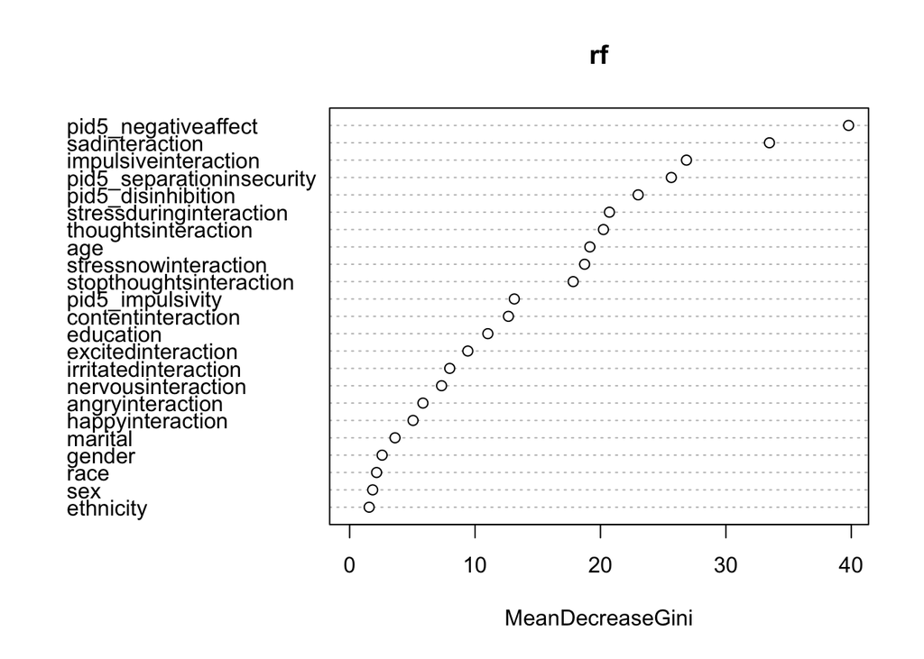

```r
varImpPlot(rf)
```

### Fit the random forest with mtry = 9 and add ID as a cluster variable

```r
# Predicting SI_Binary with random forest on the training dataset
rf=randomForest(SI_Binary~.,data=df,mtry=9,ntree=800) #use 7 vars at a time (7 random predictors as candidates to split on), 400 trees grown in bootstrapped datasets.
#obtain the predicted values in the testing dataset
rfpred=predict(rf,tsdf,type='response')
# cross-tabulation of the classes
rf.table=table(rfpred,tsdf$SI_Binary)
#the variable importance measures.
rf.table
```

```
##
## rfpred   No  Yes
##    No  1011    0
##    Yes    1   87
```

```r
1-(mean(rfpred==tsdf$SI_Binary))
```

```
## [1] 0.0009099181
```

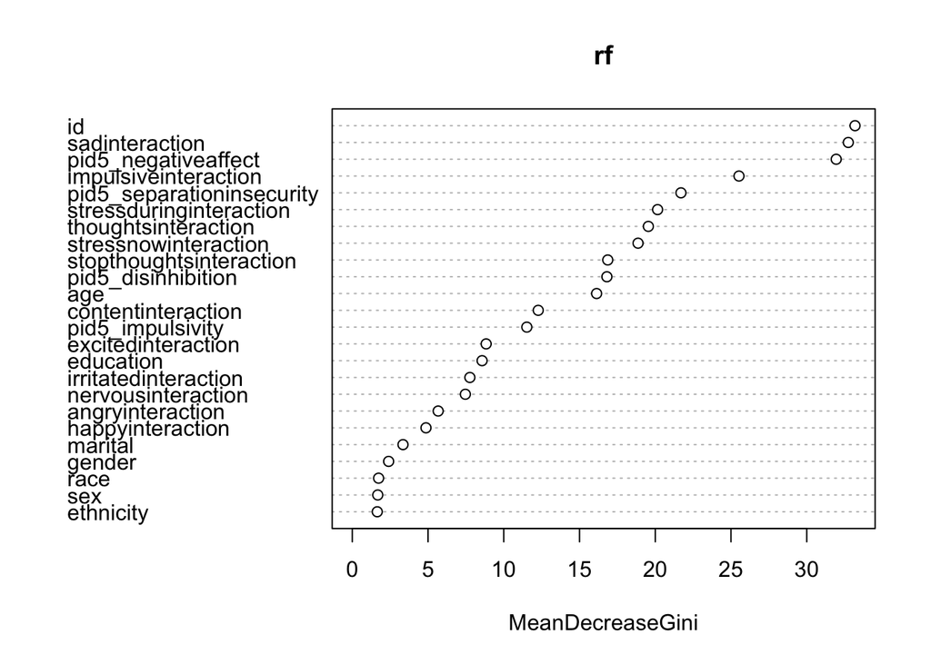

```r
varImpPlot(rf)
```

# Conditional Inference Random Forest with cforest()

```r
df[] <- lapply(df, function(x) if(is.character(x)) factor(x) else x)
tsdf[] <- lapply(tsdf, function(x) if(is.character(x)) factor(x) else x)

#crf1 <- cforest(SI_Binary ~ . - id, data = df, controls = cforest_unbiased(ntree = 400, mtry = 3))
# Make predictions on the testing dataset

#crfpred <- predict(crf1, newdata = tsdf, type = "response") # Error in checkData(oldData, RET) :  Levels in factors of new data do not match original data -- I checked and the levels of the race variable are different. This is because there is only one American Indian participant in the entire dataset and they were added to the training data.

#filter out the American Indian participant
df <- df %>% filter(race != "American Indian")
df$race <- factor(as.character(df$race, levels = "African American", "Asian","Pacific Islander" ,"White"))
tsdf$race <- factor(as.character(tsdf$race, levels = "African American", "Asian","Pacific Islander" ,"White"))
df[] <- lapply(df, function(x) if(is.character(x)) factor(x) else x)
crf1 <- cforest(SI_Binary ~ ., data = df, controls = cforest_unbiased(ntree = 800, mtry = 9))
crfpred <- predict(crf1, newdata = tsdf, type = "response")

crf.table=table(crfpred,tsdf$SI_Binary)
crf.table
```

```
##
## crfpred   No  Yes
##     No  1005   55
##     Yes    7   32
```

```r
1-(mean(crfpred==tsdf$SI_Binary))
```

```
## [1] 0.05641492
```

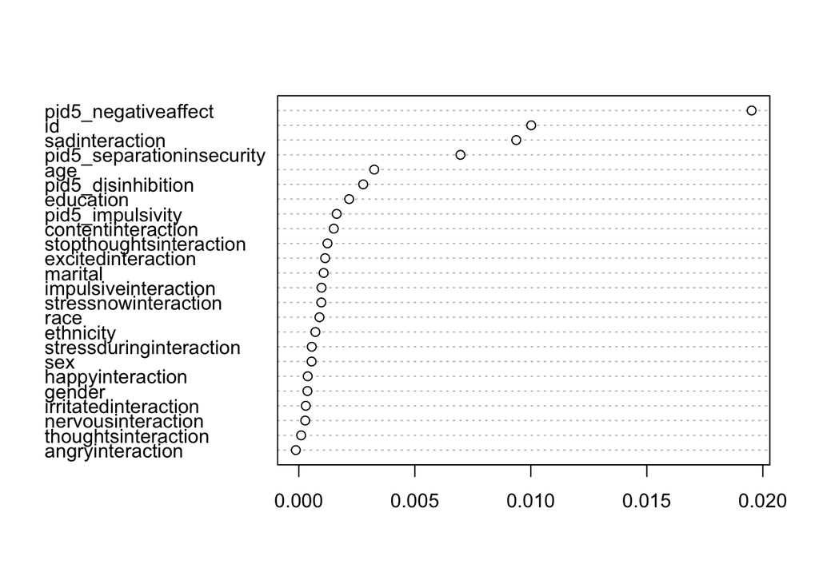

```r
vi=varimp(crf1)
dotchart(sort(vi,decreasing=FALSE))
```

## Tuning the Conditional Inference Random Forest

```r
#Fit model for conditional inference random forest
set.seed(2000)
train.crf=train(SI_Binary~.,data=df,method='cforest',tuneLength=5,trControl=trctrl)
train.crf
```

```
## Conditional Inference Random Forest
##
## 2188 samples
##   24 predictor
##    2 classes: 'No', 'Yes'
##
## No pre-processing
## Resampling: Cross-Validated (5 fold)
## Summary of sample sizes: 1751, 1751, 1751, 1749, 1750
## Resampling results across tuning parameters:
##
##   mtry  Accuracy   Kappa
##    2    0.9172772  0.0000000
##    9    0.9332715  0.3583688
##   17    0.9341890  0.4217588
##   24    0.9360175  0.4516545
##   32    0.9360165  0.4544837
##
## Accuracy was used to select the optimal model using the largest value.
## The final value used for the model was mtry = 24.
```

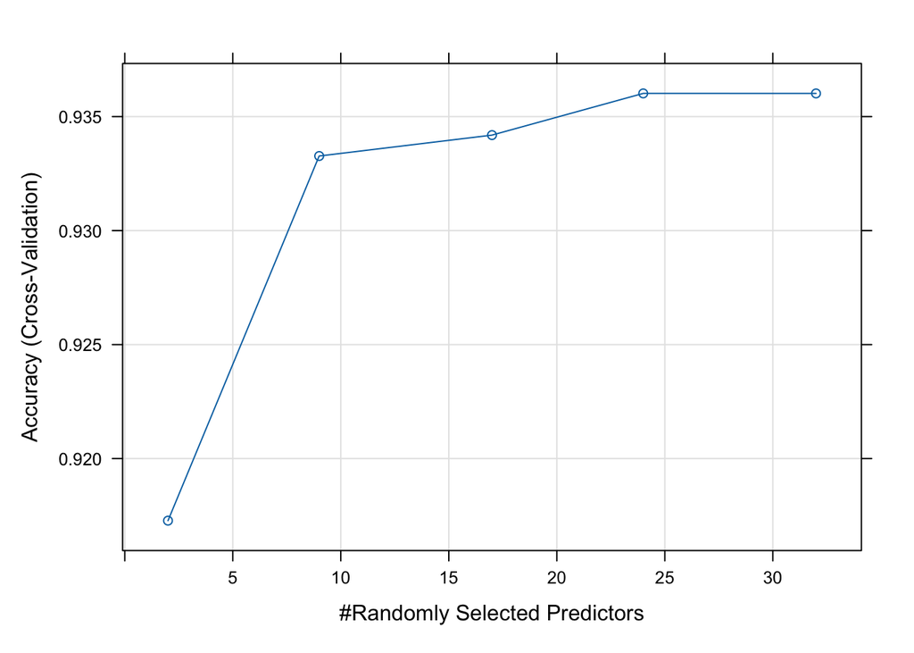

```r
plot(train.crf)
```

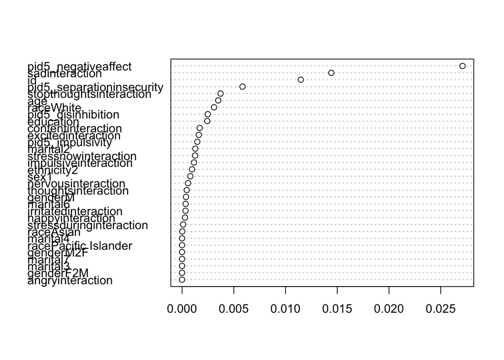

```r
final.crf=train.crf$finalModel

#plot variable importance
vi=varImp(final.crf)[,1]
names(vi)=rownames(varImp(final.crf))
dotchart(sort(vi,decreasing=FALSE))
```

### mtry = 24 conditional inference random forest

```r
crf1 <- cforest(SI_Binary ~ ., data = df, controls = cforest_unbiased(ntree = 800, mtry = 24))
crfpred <- predict(crf1, newdata = tsdf, type = "response")

crf.table=table(crfpred,tsdf$SI_Binary)
crf.table
```

```
##
## crfpred   No  Yes
##     No  1004   54
##     Yes    8   33
```

```r
1-(mean(crfpred==tsdf$SI_Binary))
```

```
## [1] 0.05641492
```

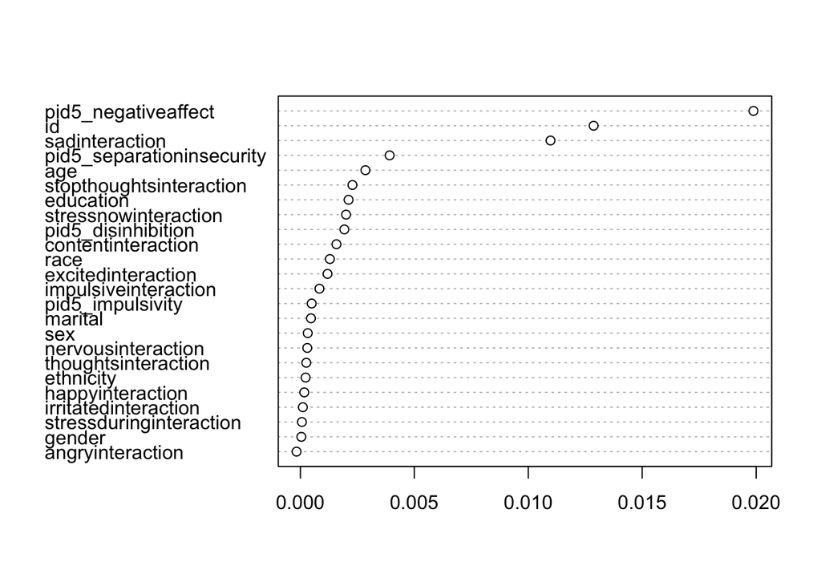

```r
vi=varimp(crf1)
dotchart(sort(vi,decreasing=FALSE))
```